# HR Exploration

Home run data downloaded from [BaseballSavant](https://baseballsavant.mlb.com).

Read all csv files in the `data` directory into a single dataframe.

Check for null values. Also need to strip out inside-the-park home runs, where the batter did not hit the ball out of the field of play.

```r
library(dplyr)
library(tidyr)
set.seed(42274)
convert_dates <- function (f) {
  a <- as.Date(f$game_date, format="%Y-%m-%d")
  b <- as.Date(f$game_date, format="%m/%d/%Y") # Produces NA when format is not "%m/%d/%Y"
  a[is.na(a)] <- b[!is.na(b)]
  f$date <- a
  return(f)
}
data_dir <- "./data/"
data_files <- list.files(path=data_dir, pattern="*_hr_data.csv", full.names=TRUE)
data <- do.call(rbind, lapply(data_files, function (x) read.csv(x, na.strings=c("null", "0", "0.0"))))
data <- convert_dates(data)
hr_hits = grep(pattern="inside-the-park", x=data$des, invert=TRUE)
data <- data[hr_hits, ]
```

Let’s examine the rate at which home runs are hit in a given season.

```r
by_year <- data %>% group_by(game_year)
years <- c(2011:2017)
colors <- rainbow(length(years))
plot(1, type='l', xlab='Day of Season', ylab='Cumulative Home Run Count', xlim=c(0,200),ylim=c(0,6000))
for (y in years) {
  year_data <- by_year %>% filter(game_year == y) %>% group_by(game_date)
  sum <- cumsum(count(year_data)$n)
  lines(sum, col=colors[y-2010])
}
```

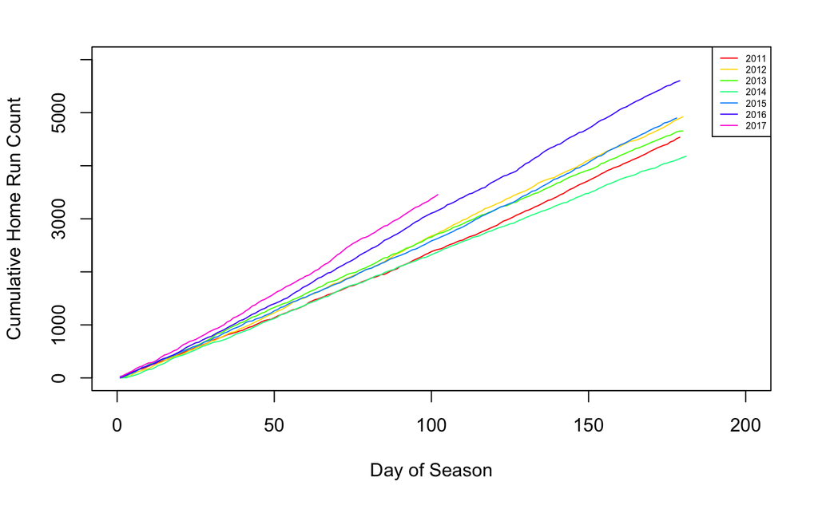

```r
legend("topright", legend = years, col = colors, lwd = 1,
       cex = 0.5)
```

There does appears to be an inflection point around Day 50 of the 2016 season. After that point, the slope of the 2016 and 2017 lines are steeper.

Unfortunately, we only have home run distance information for the 2015 season onward. First, drop all entries with no distance data. Then we can look at the distribution of distances.

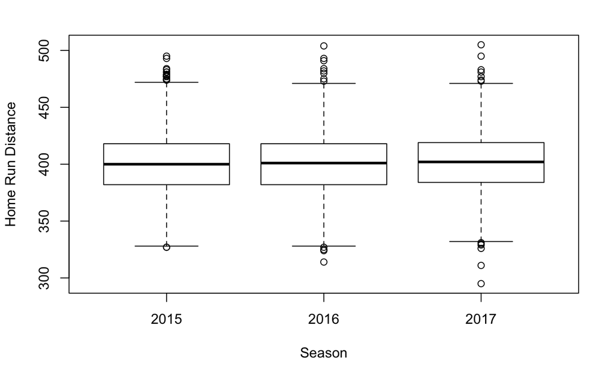

```r
clean_data <- data %>% drop_na(hit_distance_sc)
boxplot(hit_distance_sc ~ game_year, data=clean_data, xlab='Season', ylab='Home Run Distance')
```

Next we can look at the distributions

```r
years <- c(2015:2017)
colors <- rainbow(length(years))
plot(1, type='l', xlab='Home Run Distance', ylab='Number of Hits', xlim=c(275,525),ylim=c(0,115))
for (y in years) {
  year_data <- clean_data[clean_data$game_year == y, ]
  counts <- table(year_data$hit_distance_sc)
  lines(counts, col=colors[y-2014], type="l")
}
```

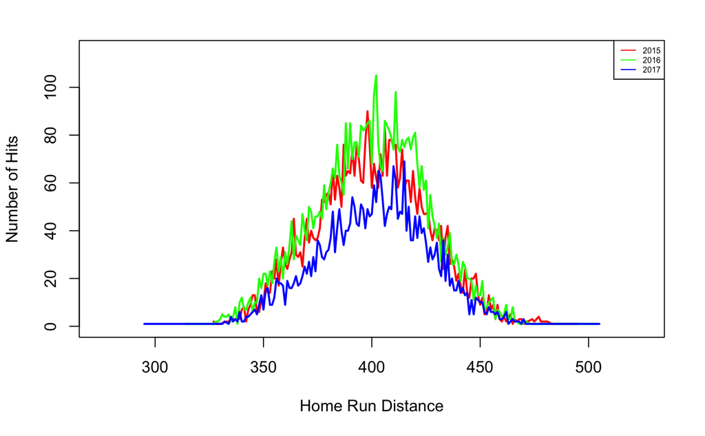

```r
legend("topright", legend = years, col = colors, lwd = 1,
       cex = 0.5)
```

What if we segment the data at the inflection point in the 2016 season?

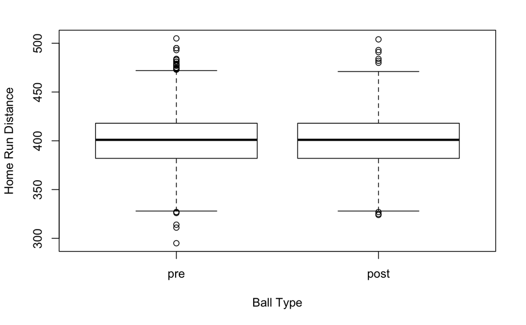

```r
clean_data <- clean_data[clean_data$game_year %in% c(2015, 2016, 2017), ]
first_day_2016 <- first(sort(clean_data[clean_data$game_year == 2016, ]$date))
set_ball_type <- function (curr_date, test_date) {
  if (curr_date['date'] <= test_date) {
    "pre"
  }
  else
  {
    "post"
  }
}
ball_type <- apply(clean_data, 1, set_ball_type, first_day_2016 + 50)
clean_data$ball_type = as.factor(ball_type)
clean_data$ball_type <- ordered(clean_data$ball_type, c("pre", "post"))
boxplot(hit_distance_sc ~ ball_type, data=clean_data, xlab='Ball Type', ylab='Home Run Distance')
```

```r
ball_types <- c("pre", "post")
colors <- rainbow(length(ball_types))
plot(1, type='l', xlab='Home Run Distance', ylab='Number of Hits', xlim=c(275,525),ylim=c(0,200))
for (bt in ball_types) {
  type_data <- clean_data[clean_data$ball_type == bt, ]
  counts <- table(type_data$hit_distance_sc)
  lines(counts, col=colors[type_data[1, ]$ball_type], type="l")
}
```

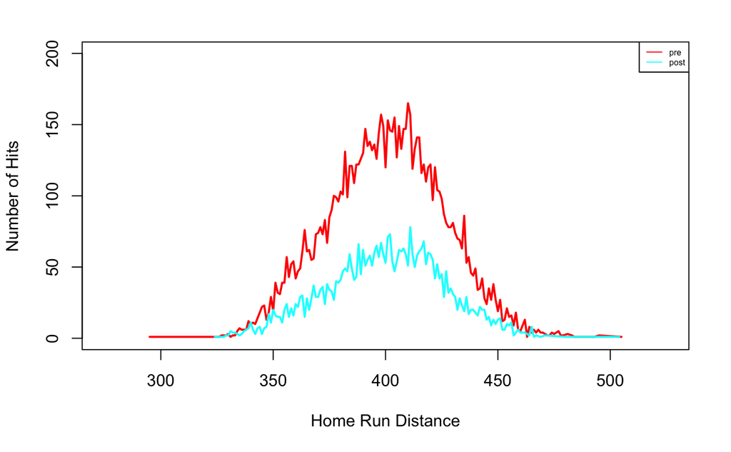

```r
legend("topright", legend = ball_types, col = colors, lwd = 1,
       cex = 0.5)
```

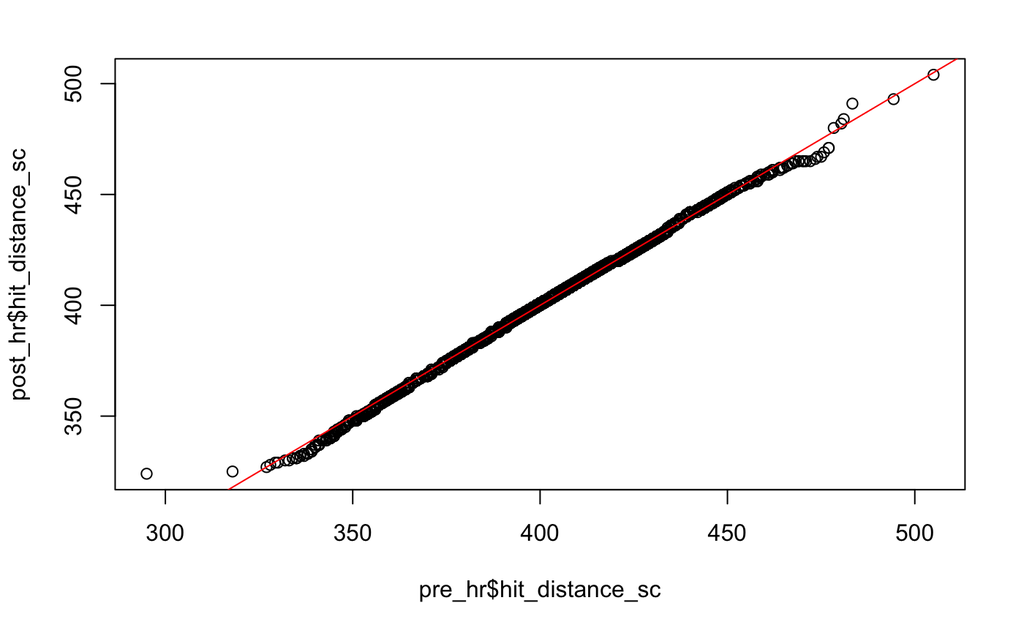

```r
pre_hr <- clean_data[clean_data$ball_type == "pre", ]
post_hr <- clean_data[clean_data$ball_type == "post", ]
qqplot(pre_hr$hit_distance_sc, post_hr$hit_distance_sc)
abline(0, 1, col="red")
```

The Quantile-Quantile plot of home run distances over the `pre` modification baseballs and `post` modification baseballs indicates that they come from populations with a common distribution.

Since we don’t see any significant difference in home run distances, let’s look at other kinds of hits during this same time period. Additional data was downloaded from StatCast, capturing all well hit, in the air, balls, regardless of the result of the play. Similar data cleaning was applied, removing empty fields.

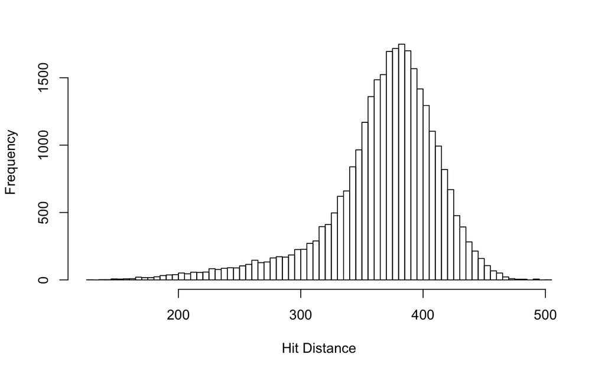

```r
hits <- read.csv(file.path(data_dir, "well_hit_data.csv"), na.strings=c("null", "0", "0.0"))
hits <- drop_na(hits, hit_distance_sc)
hits <- convert_dates(hits)
hist(hits$hit_distance_sc, breaks=80, xlab="Hit Distance", main="")
```

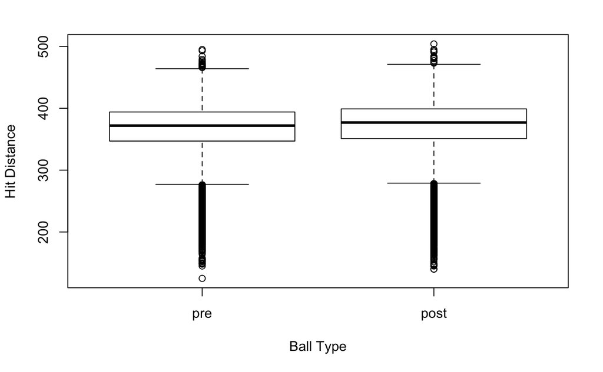

```r
ball_type <- apply(hits, 1, set_ball_type, first_day_2016 + 50)
hits$ball_type = as.factor(ball_type)
hits$ball_type <- ordered(hits$ball_type, c("pre", "post"))
boxplot(hit_distance_sc ~ ball_type, data=hits, xlab='Ball Type', ylab='Hit Distance')
```

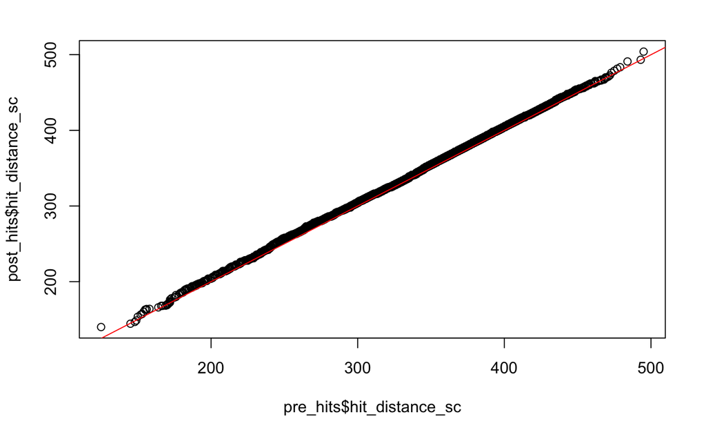

```r
pre_hits <- hits[hits$ball_type == "pre", ]
post_hits <- hits[hits$ball_type == "post", ]
qqplot(pre_hits$hit_distance_sc, post_hits$hit_distance_sc)
abline(0, 1, col="red")
```

Let’s look at the categorical data. Drop events that happen infrequently (double plays, fielding errors, sacrifice flys).

```r
drop_hits <- hits[hits$events %in% c("double", "field_out", "home_run", "single", "triple"), ]
drop_hits <- droplevels(drop_hits)
tbl <- table(drop_hits$events, drop_hits$ball_type)
print(tbl)
```

```
             pre post
  double    2320 4369
  field_out 3545 5952
  home_run  3332 7155
  single     585 1065
  triple     318  466
```

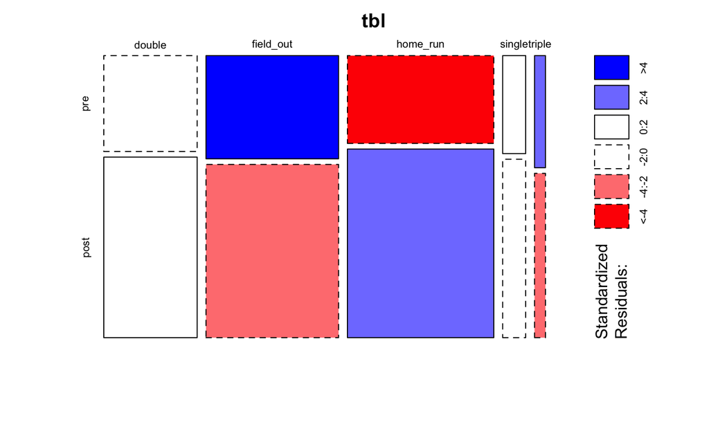

```r
mosaicplot(tbl, shade=TRUE)
```

```r
c2 = chisq.test(tbl)
print(c2)
```

```
    Pearson's Chi-squared test

data:  tbl
X-squared = 80.899, df = 4, p-value < 2.2e-16
```

Based on the results of the Chi-squared test, we can reject the null hypotheis that the ball type and the outcome of the batted ball are independent. It appears that we are getting fewer fly ball outs and triples, while increasing the number of home runs.

Let’s check with the Kruskal-Wallis test (for non-normal distributions).

```r
kw = kruskal.test(hit_distance_sc ~ ball_type, data=hits)
print(kw)
```

```
    Kruskal-Wallis rank sum test

data:  hit_distance_sc by ball_type
Kruskal-Wallis chi-squared = 90.085, df = 1, p-value < 2.2e-16
```

Based on the very small `p-value` we can reject the null hypothesis that hit distances segmented by ball type are drawn from the same population.

How about the home run balls?

```r
kw = kruskal.test(hit_distance_sc ~ ball_type, data=clean_data)
print(kw)
```

```
    Kruskal-Wallis rank sum test

data:  hit_distance_sc by ball_type
Kruskal-Wallis chi-squared = 0.011312, df = 1, p-value = 0.9153
```

If we only look at home runs segmented by ball type, we can not reject the null hypothesis. This is in line with the increased number of shorter home runs that appears after the ball type changes - presumably these are fly balls or triples that are now clearing the fence. Long home runs are still clipped at a maximum distance by striking physical objects in the stadium. If we had projected distance data, rather than actual distance data, we would expect to see long home runs increase in distance as well.